# PSYCH 413 Midterm - Due Wed Feb 26th by 09:30am

# Submission Instructions

(*ignore at your own risk*)

- Submit your responses in a `.ipynb` file.
- If you experience WiFi issues, consider using a cellphone hotspot as a temporary solution.

## Guidelines for Calculation Questions:

- Include the **R code** you used for calculations.
- Ensure **all code is executed** so that relevant outputs are visible.
- **Minimize unnecessary outputs**—only include what’s relevant.
- Round final **answers** (not intermediate steps) to **3–5 decimal places**, if necessary.
- **Support your conclusions with plots** when checking assumptions.
- Unless stated otherwise:
  - Use a significance level of $\alpha = 0.05$.
  - Set any trimming to 20%.
  - Select **tests appropriate for the data and assumptions.**
  - If assumptions of a classical test are *not violated*, use it instead of a robust alternative (it will be obvious when assumptions are violated).
- **[Good coding style matters](https://jpisklak.github.io/courses/tips.html)**—clean, organized, and well-commented code will be rewarded. Disorganized, redundant, or poorly structured code may lose marks.

### The following functions are NOT permitted:

#### `t.test()`, `cohen.d()`, `yuen()`, `mad()`

- Functions from other packages that perform equivalent calculations to these functions are also disallowed.
- **Only use R packages covered in class.** Packages not introduced in class are **not permitted** and will result in an automatic 0 for any question in which they are used.
- Code which deviates significantly from the norm or appears to be copied mindlessly from external sources will receive a preliminary score of 0. To recover marks, you will be required to explain your code in person.

# Question 1

Pinky is a mouse participating in a top secret neuropsychology study at the infamous ACME labs. The study’s data can be found in `ACME_labs_top_secret.csv`. Pinky has a `id` number of `"dq3nas"`.

[figure not shown]

## a.

Using a normal distribution to model this data set, how many standard deviations above or below the mean was Pinky relative to his other lab mates and what percentile does this place him at? Use **population** level statistics.

```r
library(tidyverse)
acme <- read_csv("https://docs.google.com/uc?id=1JTvLqY5Fqt-b8RjaQlu08IrdCE4-anup&export=download")

# Pinky's score
pinky <- acme$value[acme$id == "dq3nas"]

# Pinky's z-score (i.e., std. deviations from the mean)
N <- nrow(acme)
m <- mean(acme$value)
s <- sqrt(sum((acme$value - m)^2) / N) # Pop. SD
z <- (pinky - m) / s
z
```

```
## [1] 0.09720916
```

```r
# Percentile - Two-ways of solving this:
percentile <- 100 * pnorm(z, mean = 0, sd = 1)
# or
percentile <- 100 * pnorm(pinky, mean = m, sd = s)
percentile
```

```
## [1] 53.87199
```

Pinky is 0.0972 standard deviations ABOVE the mean.

Pinky is at the 53.87 percentile.

## b.

Pinky’s best friend in the whole wide world, “Brain”, scored approximately at the 1st percentile. Based on the data from the previous question, what can we infer Brain’s score in this study to be?

```r
brain <- qnorm(0.01, mean = m, sd = s)
brain
```

```
## [1] 67.91102
```

## c.

What is the probability that any mouse in ACME Lab’s study has a score greater than $109$?

```r
p <- pnorm(109, mean = m, sd = s, lower.tail = FALSE)
round(p, 4)
```

```
## [1] 0.3041
```

## d.

What score would a mouse need to be at least two standard deviations above the mean score?

```r
z <- 2

# Rearrange the z-score formula (z = (x - m)/s )
x <- z * s + m
round(x, 4)
```

```
## [1] 130.5278
```

## e.

What percentage of mice in the sample would you expect to be between $85.52$ and $138.92$?

```r
bot_val <- 85.52
top_val <- 138.92

# Just subtract the percentiles
top_perc <- pnorm(top_val, mean = m, sd = s) * 100
bot_perc <- pnorm(bot_val, mean = m, sd = s) * 100
diff_perc <- top_perc - bot_perc

diff_perc
```

```
## [1] 86.14933
```

# Question 2.

Over the span of many days, and for reasons known only to himself, Brain would count the amount of vocal tics his friend Pinky engaged in within a 24 hour period. He collected a number of observations and, being the scientific genius he is, plotted them using as a histogram (seen below). What is $\bar{x}$?

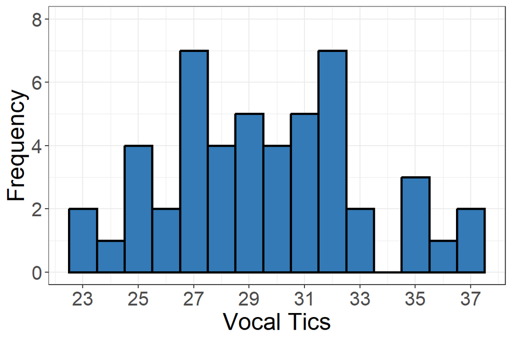

```r
tics <- 23:37
weights <- c(2, 1, 4, 2, 7, 4, 5, 4, 5, 7, 2, 0, 3, 1, 2)

# Weighted mean
sum(weights * tics) / sum(weights)
```

```
## [1] 29.55102
```

# Question 3.

The data set `screentime.csv` contains the average daily phone screen time for boomers and zoomers. Create a single graph that displays boxplot for each generation. Give the axes an appropriate labels.

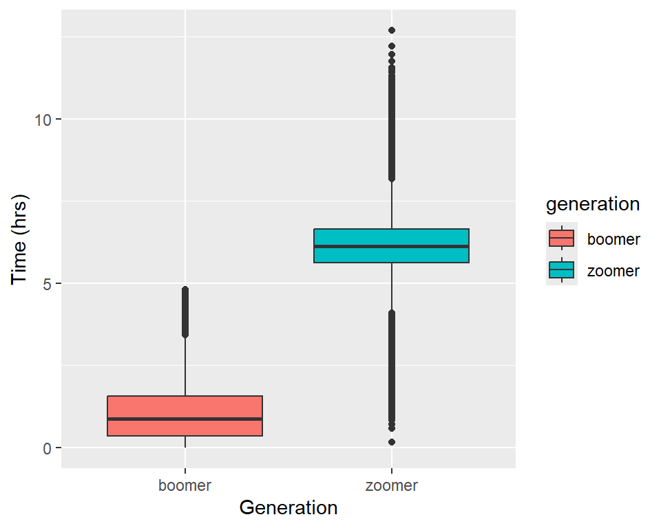

```r
library(tidyverse)
phone <- read_csv("https://docs.google.com/uc?id=17DNsh9_fzO0jczIQBg3Hv8GYExzPMSu2&export=download")

ggplot(phone, aes(x = generation, y = time_hr)) +
  geom_boxplot(aes(fill = generation)) +
  xlab("Generation") + ylab("Time (hrs)")
```

# Question 4.

Using the boxplot rule for outlier detection, write R code that determines how many outliers there are in the “boomer” generation.

```r
# Isolate boomers
boom <- filter(phone, generation == "boomer")

# Get quantiles
q1 <- quantile(boom$time_hr)[2]
q3 <- quantile(boom$time_hr)[4]
iqr <- IQR(boom$time_hr)

# Get whisker boundires
bot_whisk <- q1 - 1.5 * iqr
top_whisk <- q3 + 1.5 * iqr

# Filter outliers
out_box <- filter(boom, time_hr < bot_whisk | time_hr > top_whisk)

# Amount of Outliers
nrow(out_box)
```

```
## [1] 10021
```

# Question 5.

Using a robust rule for outlier detection, write R code that determines how many outliers are in the “boomer” generation.

```r
# Calculate MADN stat.
madn <- median(abs(boom$time_hr - median(boom$time_hr))) / 0.6745

# Determine outliers
boom$out_mad <- abs(boom$time_hr - median(boom$time_hr)) / madn > 2.24

# Amount of Outliers
nrow(filter(boom, out_mad == TRUE))
```

```
## [1] 43817
```

# Question 6.

## a.

The media claims zoomers spend an average of 6 hours a day on their phones. Given the `screentime.csv` data, and taking into account test assumptions, what would be an **appropriate** type of test to run here to evaluate the media’s claim?

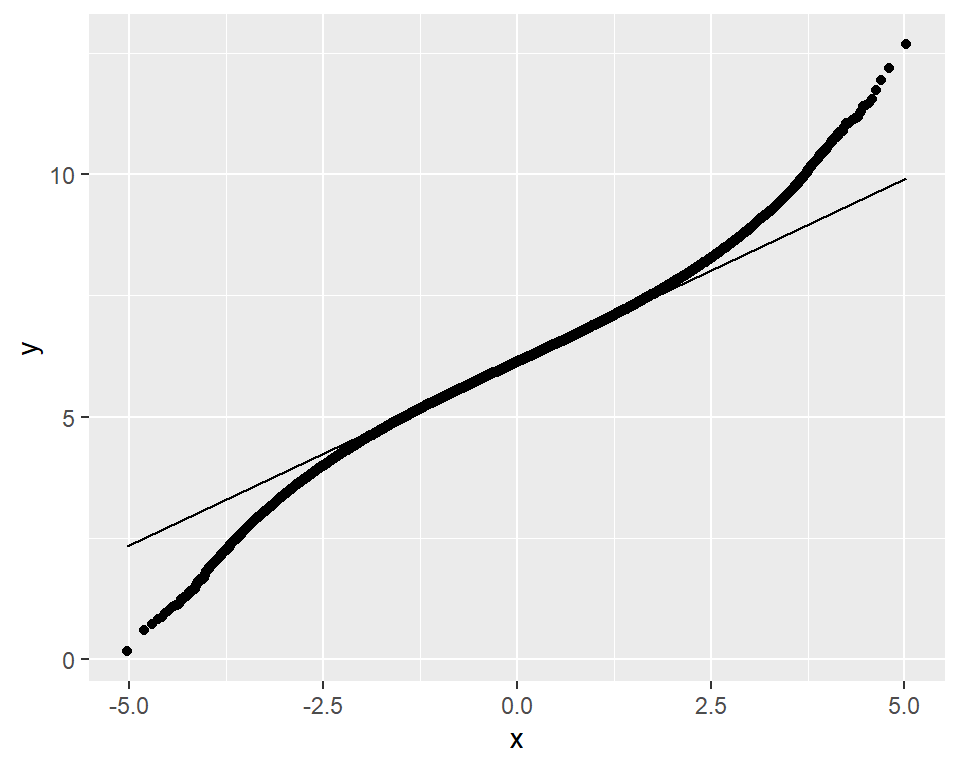

```r
# Isolate zoomers for simplicity
zoom <- filter(phone, generation == "zoomer")

#Q-Q Plot
ggplot(zoom, aes(sample = time_hr)) +
  stat_qq() +
  stat_qq_line()
```

Since the normality assumption is violated and we are working with a single sample/mean. A trimmed one-sample t-test is best.

## b.

Conduct the test you specified to assess the media’s claim.

Ensure the test is designed so that, if the media are right, the probability of incorrectly rejecting their claim is only 1 in 100.

Please ensure the following statistics are reported:

- Null & Alternative Hypotheses
- Test statistic
- Degrees of freedom
- p-value
- Confidence interval
- Your conclusion with respect to the hypothesis.

```r
library(WRS2)

# Sample Size
N <- nrow(zoom)

# Amount of Trimming
G <- 0.2

# Trimmed mean
m <- mean(zoom$time_hr, tr = G)

# Winsorized Variance and Standard Deviation
var <- winvar(zoom$time_hr, tr = G)
s <- sqrt(var)

# Standard Error of Trimmed Mean
se <- s / ((1-2*G) * sqrt(N))

# Degrees of Freedom
h <- N - 2 * floor(G * N)
df <- h - 1

# Critical T
alpha <- 0.01
t_crit <- abs(qt(alpha/2, df = df))

# 95% CI
lower <- m - t_crit * se
upper <- m + t_crit * se
ci <- paste("[", round(lower, 4), ', ', round(upper, 4), ']', sep = '')

# Test stat
mu <- 6
t <- (m - mu) / se

p <- pt(t, df = df, lower.tail = FALSE) * 2
```

```
## T = 221.8984
```

```
## df = 1157764
```

```
## p = 0
```

```
## 99% CI = [6.1281, 6.1311]
```

$H_0: \mu = 6$

$H_1: \mu \neq 6$

The null hypothesis is rejected.

## c.

Considering the values obtained in the above analysis, do you believe the media’s claim is unreasonable? Why? (No calculation is required for this question)

- The estimated mean population screentime is $6.13$ hours, while the media claims it to be 6 hours. This represents a difference of approximately 7.8 minutes. Although this difference is statistically significant, it is unlikely to be practically meaningful for most people. Therefore, the media’s claim is not unreasonable.

# Question 7.

Suppose you are a researcher interested in examining the effect of sleep deprivation on mood. You run a controlled study where participants are randomly assigned to one of two groups:

**Sleep-Deprivation Group:** Participants remain awake for 24 hours.

**Normal Sleep Group:** Participants follow their regular sleep schedule.

After the treatment, participants have their cortisol levels measured in micrograms per deciliter (µg/dL). The results are in `sleep.csv`.

Your hypothesis is that cortisol levels will be higher in the sleep-deprived group. Based on the results conduct an **appropriate** test that evaluates whether your hypothesis should be *accepted.*

Please ensure the following are reported:

- Name of the test you are running
- Null & Alternative Hypotheses
- Test statistic
- degrees of freedom
- Confidence Interval
- p-value
- Your conclusion with respect to the hypothesis.

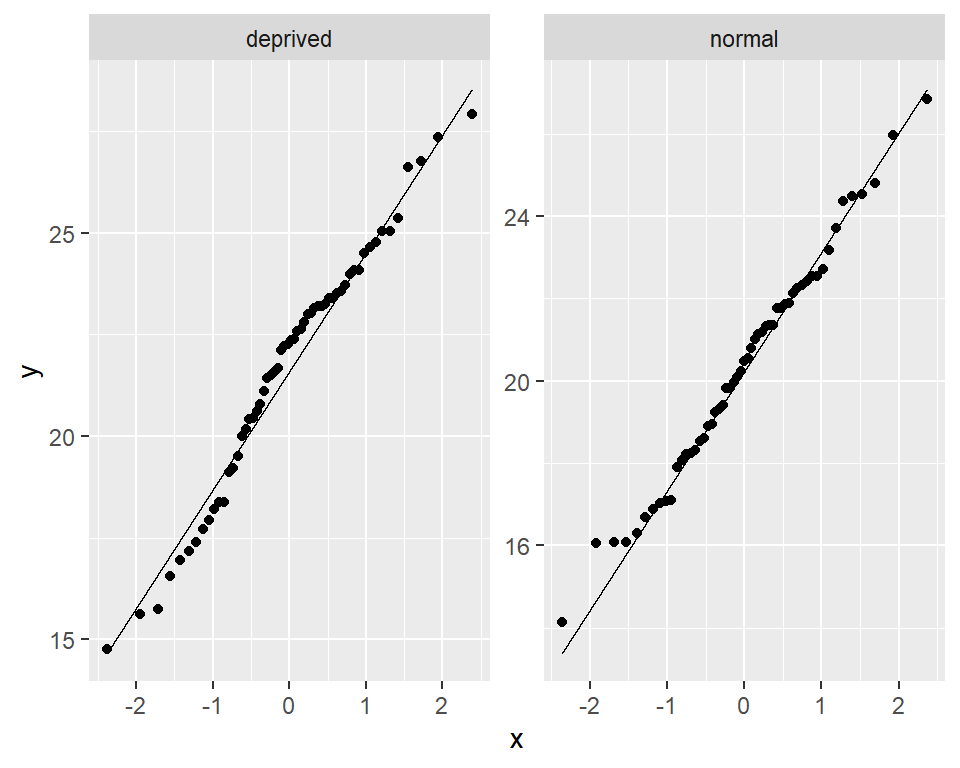

```r
# Load data
sleep <- read_csv("https://docs.google.com/uc?id=1gcoKt3Sg_bxMAaRx5m_fhdlJQbQYFvyU&export=download")

# Check normality assumption
ggplot(sleep, aes(sample = cortisol)) +
  stat_qq() +
  stat_qq_line() +
  facet_wrap(~ condition, scales = "free")
```

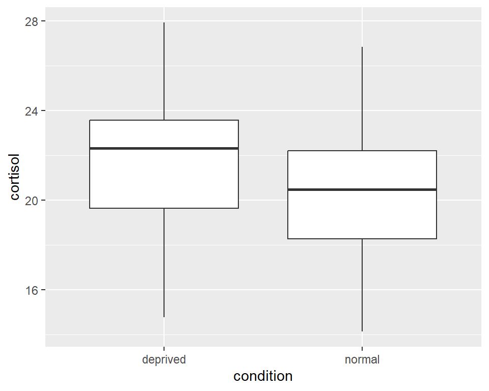

```r
# Check homogeneity of variance
ggplot(sleep, aes(x = condition, y = cortisol)) +
  geom_boxplot()
```

Since the assumptions of a classic two sample t-test are met, that will be run.

$H_0: \mu_{_\text{depr}} - \mu_{_\text{norm}} \leq 0$

$H_1: \mu_{_\text{depr}} - \mu_{_\text{norm}} > 0$

```r
stats <- sleep |>
  group_by(condition) |>
  summarise(
    n = length(cortisol),
    m = mean(cortisol),
    v = var(cortisol)
  )

# Pooled var
# Note we can use the fact that the stats are in columns/vectors to save us some typing.
# Alternatively, you could type out the whole formula.
var_p <- sum((stats$n - 1) * stats$v) / (sum(stats$n) - 2)

# Std Error
se <- sqrt(sum(var_p / stats$n))

# Degrees of freedom
df <- sum(stats$n) - 2

# Critical t score
alpha <- 0.05
t_crit <- abs(qt(alpha, df = df))

# 95% CI
m_diff <- (stats$m[1] - stats$m[2])
bot <- m_diff - t_crit * se
top <- Inf
ci <- paste0("[", round(bot, 3), ", ", top, ")")

# Test-stat
mu <- 0
t_stat <- (m_diff - mu) / se

# P-value
p <- pt(t_stat, df = df, lower.tail = FALSE)
```

```
## Test Stat =  2.4784
```

```
## df =  111
```

```
## p =  0.0074
```

```
## 95% CI =  [0.451, Inf)
```

We reject the null hypothesis that the mean difference is less than or equal to 0 and accept the alternative hypothesis that it is greater. i.e., we accept the hypothesis that sleep deprivation increases cortisol levels.

# Question 8.

For each of the following, indicate whether you expect the distribution to be symmetric, negatively skewed, or positively skewed. Also state whether the mean or median would best represent the central tendency.

## a.

Reaction time of a rat pressing a lever for immediate food delivery.

- positively skewed; median.

## b.

Percentages on a very difficult economics exam that had high variability.

- positively skewed; median.

# Question 9.

## a.

Suppose you measure your rate of swearing per hour. What scale of measurement would this be?

- Ratio

## b.

What scale of measurement would differences between rates of swearing be?

- Ratio

# Question 10.

A student was walking through CAB one day on their way to Timmies and stumbled on some mysterious data in a treasure chest. The data can be seen in `mystery_data.csv`. Plot the data as a bar graph so significance can be assessed adequately. Use trimming if necessary.

- Include error bars that represent the standard error of the mean (SEM).
- Neatly display the descriptive statistics used to create the plot.

```r
# Load data
data <- read_csv("https://docs.google.com/uc?id=1Ux4MSN45EMKhyadg0YhyKcJr3i-KJKax&export=download")

# Notice that the data contains paired values
head(data)
```

```
## # A tibble: 6 × 3
##   subject        x_1         x_2
##     <dbl>      <dbl>       <dbl>
## 1       1 -3681.150   -519.4119
## 2       2  2673.911   -757.1523
## 3       3  2609.249    543.0510
## 4       4  1097.166    -48.61839
## 5       5  1248.209   2669.757
## 6       6  -411.7093 -3390.026
```

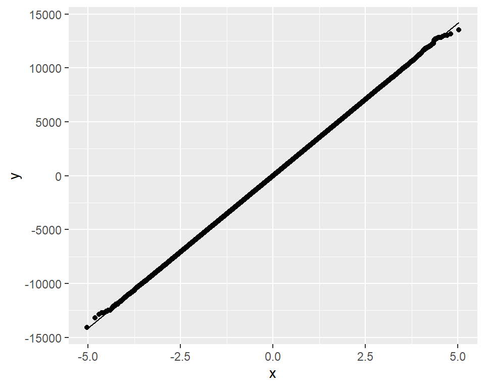

```r
# Add difference scores
data$diff <- data$x_1 - data$x_2

# Evaluate normality (data is very normal)
ggplot(data, aes(sample = diff)) +
  stat_qq() +
  stat_qq_line()
```

```r
# Get plot data
plot_data <- data |>
  pivot_longer(cols = c(x_1, x_2, diff), names_to = "group") |> # tidy data
  group_by(group) |>
  summarise(
    n = length(value),
    m = mean(value),
    se = sd(value) / sqrt(n)
  )

plot_data
```

```
## # A tibble: 3 × 4
##   group       n         m       se
##   <chr>   <int>     <dbl>    <dbl>
## 1 diff  1982686 -5.912617 2.010181
## 2 x_1   1982686 -3.034866 1.421595
## 3 x_2   1982686  2.877751 1.421292
```

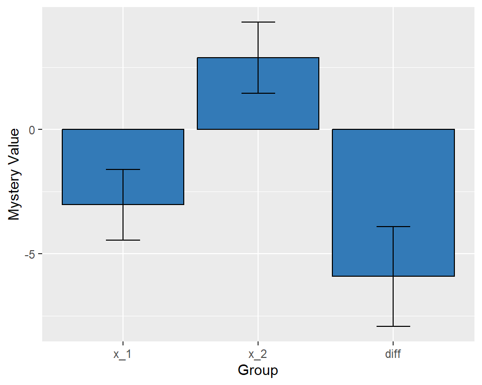

```r
# Factor to put values in sensible order
plot_data$group <- factor(plot_data$group, levels = c("x_1", "x_2", "diff"))

#Plot
ggplot(plot_data, aes(x = group, y = m)) +
  geom_bar(stat = "identity", fun = mean, colour = "black", fill = "#337AB7") +
  geom_errorbar(aes(ymin = m - se, ymax = m + se), width = .25) +
  xlab("Group") + ylab("Mystery Value")
```